# FIN_654_WK2_R

Kendra Osburn

7/14/2019

# UNIT 2 | R Data Model

## 2.1: Readings

## 2.2: Previously on Financial Analytics

## 2.3: Pivot and Parry

### Pivot Tables

1a. Read CSV *The str() function allows us to see all of the objects in CreditCard* NOTE: If it’s in a data frame, we can subset it!

```r
CreditCard <- read.csv("data/CreditCard.csv")
str(CreditCard)
```

```
## 'data.frame':    1319 obs. of  13 variables:
##  $ card       : Factor w/ 2 levels "no","yes": 2 2 2 2 2 2 2 2 2 2 ...
##  $ reports    : int  0 0 0 0 0 0 0 0 0 0 ...
##  $ age        : num  37.7 33.2 33.7 30.5 32.2 ...
##  $ income     : num  4.52 2.42 4.5 2.54 9.79 ...
##  $ share      : num  0.03327 0.00522 0.00416 0.06521 0.06705 ...
##  $ expenditure: num  124.98 9.85 15 137.87 546.5 ...
##  $ owner      : Factor w/ 2 levels "no","yes": 2 1 2 1 2 1 1 2 2 1 ...
##  $ selfemp    : Factor w/ 2 levels "no","yes": 1 1 1 1 1 1 1 1 1 1 ...
##  $ dependents : int  3 3 4 0 2 0 2 0 0 0 ...
##  $ months     : int  54 34 58 25 64 54 7 77 97 65 ...
##  $ majorcards : int  1 1 1 1 1 1 1 1 1 1 ...
##  $ active     : int  12 13 5 7 5 1 5 3 6 18 ...
##  $ state      : Factor w/ 3 levels "CT","NJ","NY": 3 3 3 3 3 3 3 3 3 3 ...
```

1b. See inside CreditCard Object

```r
head(CreditCard)
```

```
##   card reports      age income       share expenditure owner selfemp
## 1  yes       0 37.66667 4.5200 0.033269910  124.983300   yes      no
## 2  yes       0 33.25000 2.4200 0.005216942    9.854167    no      no
## 3  yes       0 33.66667 4.5000 0.004155556   15.000000   yes      no
## 4  yes       0 30.50000 2.5400 0.065213780  137.869200    no      no
## 5  yes       0 32.16667 9.7867 0.067050590  546.503300   yes      no
## 6  yes       0 23.25000 2.5000 0.044438400   91.996670    no      no
##   dependents months majorcards active state
## 1          3     54          1     12    NY
## 2          3     34          1     13    NY
## 3          4     58          1      5    NY
## 4          0     25          1      7    NY
## 5          2     64          1      5    NY
## 6          0     54          1      1    NY
```

1c. Get a Summary

```r
summary(CreditCard)
```

```
##   card         reports             age              income
##  no : 296   Min.   : 0.0000   Min.   : 0.1667   Min.   : 0.210
##  yes:1023   1st Qu.: 0.0000   1st Qu.:25.4167   1st Qu.: 2.244
##             Median : 0.0000   Median :31.2500   Median : 2.900
##             Mean   : 0.4564   Mean   :33.2131   Mean   : 3.365
##             3rd Qu.: 0.0000   3rd Qu.:39.4167   3rd Qu.: 4.000
##             Max.   :14.0000   Max.   :83.5000   Max.   :13.500
##      share            expenditure       owner     selfemp
##  Min.   :0.0001091   Min.   :   0.000   no :738   no :1228
##  1st Qu.:0.0023159   1st Qu.:   4.583   yes:581   yes:  91
##  Median :0.0388272   Median : 101.298
##  Mean   :0.0687322   Mean   : 185.057
##  3rd Qu.:0.0936168   3rd Qu.: 249.036
##  Max.   :0.9063205   Max.   :3099.505
##    dependents         months         majorcards         active
##  Min.   :0.0000   Min.   :  0.00   Min.   :0.0000   Min.   : 0.000
##  1st Qu.:0.0000   1st Qu.: 12.00   1st Qu.:1.0000   1st Qu.: 2.000
##  Median :1.0000   Median : 30.00   Median :1.0000   Median : 6.000
##  Mean   :0.9939   Mean   : 55.27   Mean   :0.8173   Mean   : 6.997
##  3rd Qu.:2.0000   3rd Qu.: 72.00   3rd Qu.:1.0000   3rd Qu.:11.000
##  Max.   :6.0000   Max.   :540.00   Max.   :1.0000   Max.   :46.000
##  state
##  CT:442
##  NJ:472
##  NY:405
##
##
##
```

2a. Check data (and filter if necessary)

```r
ccard <- CreditCard[CreditCard$age >= 18, ]
```

2b. Do a visual check

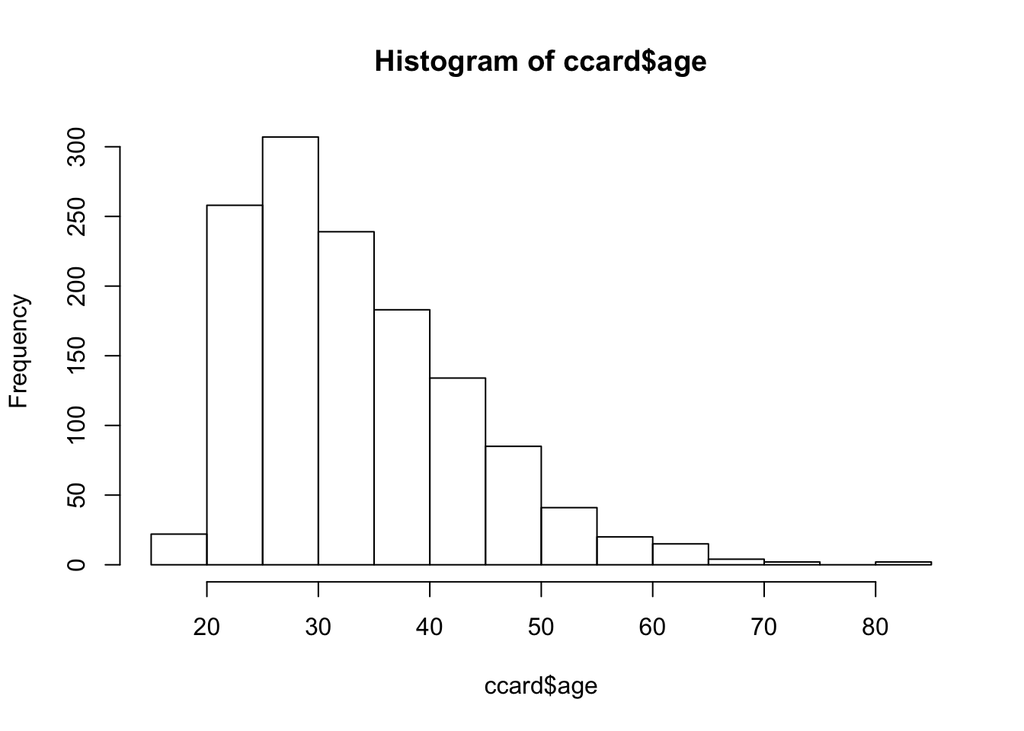

```r
hist(ccard$age)
```

3. BUILD THAT PIVOT TABLE 3a. Filter to keep NY

```r
library(dplyr)
pivot.table <- filter(ccard, state %in% "NY")
```

3b. Set up data frame forb by-group processing *group_by(dataframe, feature, feature, feature)*

```r
pivot.table <- group_by(pivot.table, card, owner, selfemp)
```

3c. Calculate the summary metrics

```r
options(dplyr.width = Inf) ## to display all columns
pivot.table <- summarise(pivot.table,
  income.cv = sd(income)/mean(income),
  age.avg = mean(age), income.per.dependent = sum(income)/sum(dependents))
```

3d. Knit it together!

```r
knitr::kable(pivot.table)
```

[output not shown]

```r
le <- read.csv("data/life_expectancy.csv", header = TRUE, stringsAsFactors = FALSE)
sa <- read.csv("data/sanitation_.csv", header = TRUE, stringsAsFactors = FALSE)
```

Replicate this in R VLOOKUP(country, sanitation, 2, FALSE) - In below example, country is our key

```r
life.sanitation <- merge(
  le[, c("country","years.life.expectancy.avg")],
  sa[, c("country", "sanitation.avg")])

# str(life.sanitation)
head(life.sanitation, 20)
```

```
##                country years.life.expectancy.avg sanitation.avg
## 1          Afghanistan                  46.62135       25.39600
## 2              Albania                  71.11807       85.36154
## 3              Algeria                  61.81652       84.21538
## 4               Angola                  41.65847       36.00769
## 5  Antigua and Barbuda                  69.81219       84.59091
## 6            Argentina                  70.64907       92.16538
## 7              Armenia                  70.23607       89.44583
## 8                Aruba                  71.94600       98.08077
## 9            Australia                  75.95027      100.00000
## 10             Austria                  74.60614      100.00000
## 11          Azerbaijan                  65.66391       73.55909
## 12             Bahrain                  69.45920       99.13846
## 13          Bangladesh                  57.40152       47.89231
## 14            Barbados                  69.56837       88.41538
## 15             Belarus                  69.76056       94.73077
## 16             Belgium                  74.96248       99.50000
## 17              Belize                  68.06791       84.10385
## 18               Benin                  49.80600       13.30000
## 19             Bermuda                  77.44577             NA
## 20              Bhutan                  50.13744       34.94615
```

TRY THIS OUT 1. Get data & view summary

```r
hprice <- read.csv("data/hprice.csv")
summary(hprice)
```

```
##        ID             Price             SqFt         Bedrooms
##  Min.   :  1.00   Min.   : 69100   Min.   :1450   Min.   :2.000
##  1st Qu.: 32.75   1st Qu.:111325   1st Qu.:1880   1st Qu.:3.000
##  Median : 64.50   Median :125950   Median :2000   Median :3.000
##  Mean   : 64.50   Mean   :130427   Mean   :2001   Mean   :3.023
##  3rd Qu.: 96.25   3rd Qu.:148250   3rd Qu.:2140   3rd Qu.:3.000
##  Max.   :128.00   Max.   :211200   Max.   :2590   Max.   :5.000
##    Bathrooms         Offers      Brick    Neighborhood
##  Min.   :2.000   Min.   :1.000   No :86   East :45
##  1st Qu.:2.000   1st Qu.:2.000   Yes:42   North:44
##  Median :2.000   Median :3.000            West :39
##  Mean   :2.445   Mean   :2.578
##  3rd Qu.:3.000   3rd Qu.:3.000
##  Max.   :4.000   Max.   :6.000
```

2. CLEARLY DEFINE BUSINESS QUESTIONS – 1. What are the most valuable (higher price) neighborhoods? (NEIGHBORHOOD is factor here) – 2. What housing characteristics maintain the most housing value? (BRICK as feature is factor here)
3. Create pivot table with summary stats to answer this question

```r
library(dplyr)
pivot.table <- filter(hprice, Price > 99999)
pivot.table <- group_by(pivot.table, Neighborhood, Brick)
options(dplyr.width = Inf) ## to display all columns
pivot.table <- summarise(pivot.table,
  price.avg = mean(Price),
  price.cv = sd(Price)/mean(Price),
  sqft.avg = mean(SqFt),
  price.per.sqft = mean(Price)/mean(SqFt))

knitr::kable(pivot.table)
```

| Neighborhood | Brick | price.avg | price.cv | sqft.avg | price.per.sqft |
| --- | --- | --- | --- | --- | --- |
| East | No | 121095.7 | 0.1251510 | 2019.565 | 59.96125 |
| East | Yes | 135468.4 | 0.0977973 | 2031.053 | 66.69863 |
| North | No | 115307.1 | 0.0939797 | 1958.214 | 58.88382 |
| North | Yes | 118457.1 | 0.1308498 | 1857.143 | 63.78462 |
| West | No | 148230.4 | 0.0912350 | 2073.478 | 71.48878 |
| West | Yes | 175200.0 | 0.0930105 | 2091.250 | 83.77764 |

## 2.4: What’s a Function?

```r
NPV.1 <- function(rates, cashflows){
  NPV <- sum(cashflows/(1+rates) ^ (seq_along(cashflows) - 1))
    return(NPV)
}
# Generating fake data for testing
rates <- c(0, 0.08, 0.06, 0.04)
cashflows <- c(-100, 200, 300, 10)
NPV.1(rates, cashflows)
```

```
## [1] 361.0741
```

#### What should be a function?

- Things that are going to be rerun
- Things we keep copy/pasting
- Chunks of code that are smaller parts of bigger analyses
- Chunks of code that are similar to other chunks

#### What if errors? Add “stopifnot”

```r
NPV.2 <- function(rates, cashflows){
  # stop if not TRUE
  stopifnot(length(rates) == length(cashflows))
  NPV <- sum(cashflows/(1+rates) ^ (seq_along(cashflows) - 1))
    return(NPV)
}
```

## 2.5: Make Distributions

```r
require(xts)
require(zoo)
EIUIR <- read.csv("data/EIUIR.csv")
head(EIUIR)
```

```
##         Date Value
## 1 2006-01-01 113.7
## 2 2006-02-01 112.8
## 3 2006-03-01 112.7
## 4 2006-04-01 115.1
## 5 2006-05-01 117.2
## 6 2006-06-01 117.3
```

```r
# get rid of NAs
xmprice <- na.omit(EIUIR)
str(xmprice)
```

```
## 'data.frame':    131 obs. of  2 variables:
##  $ Date : Factor w/ 131 levels "2006-01-01","2006-02-01",..: 1 2 3 4 5 6 7 8 9 10 ...
##  $ Value: num  114 113 113 115 117 ...
```

```r
xmprice.r <- as.zoo(na.omit((diff(log(xmprice$Value)))))
head(xmprice.r)
```

```
##             1             2             3             4             5
## -0.0079470617 -0.0008869180  0.0210718947  0.0180805614  0.0008528785
##             6
##  0.0076433493
```

Plot it

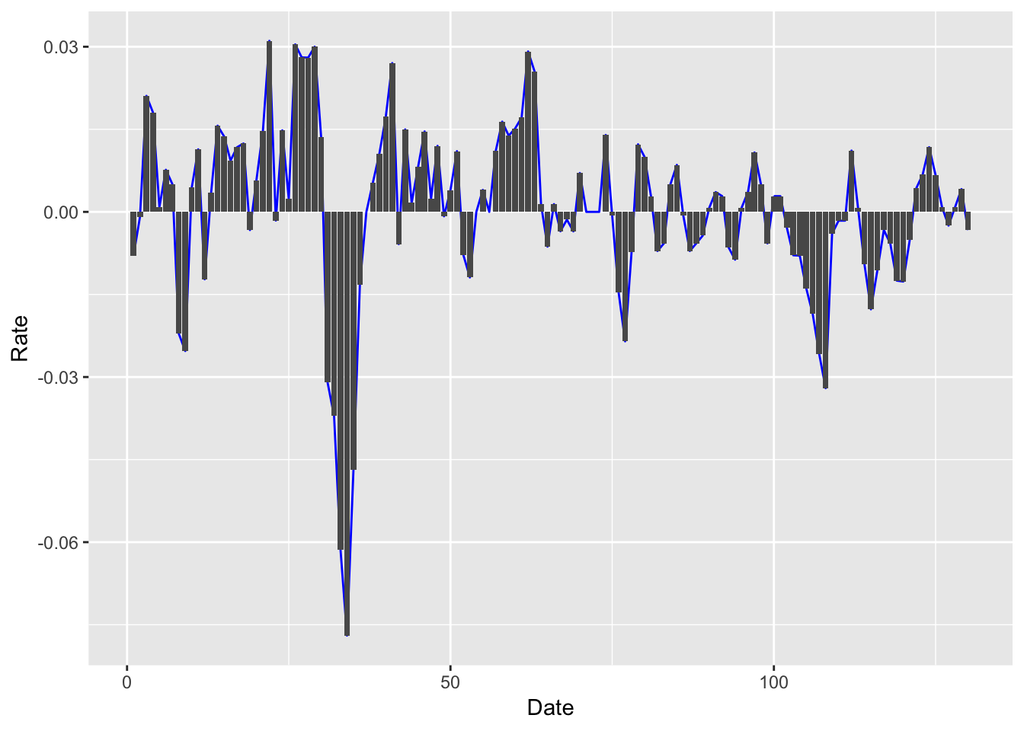

```r
library(ggplot2)
xmprice.r.df <- data.frame(xmprice.r,
    Date = index(xmprice.r), Rate = xmprice.r[,
        1], Rate.abs <- abs(xmprice.r[,
        1]))
ggplot(xmprice.r.df, aes(x=Date, y = Rate)) +
  geom_line(color = "blue") +
  geom_bar(stat = "identity")
```

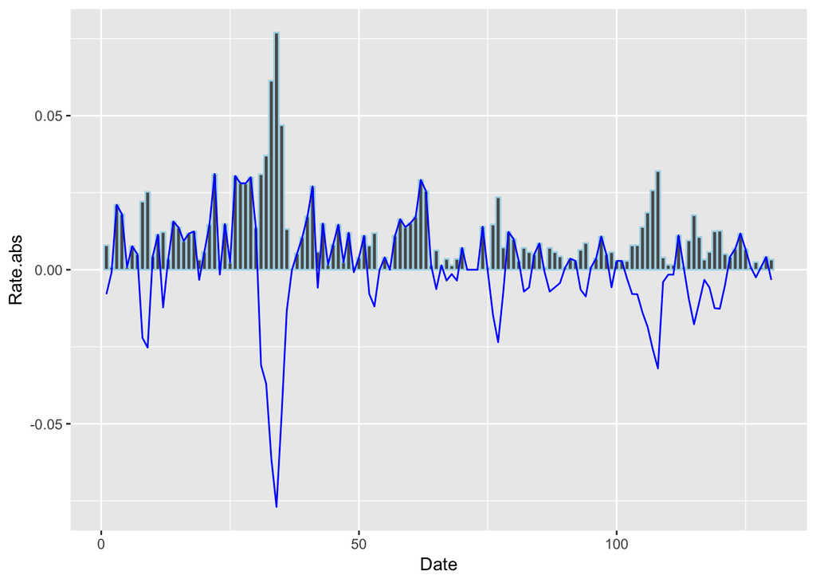

```r
ggplot(xmprice.r.df, aes(Date, Rate.abs)) +
  geom_bar(stat = "identity", color = "lightblue") +
  geom_line(data = xmprice.r.df, aes(Date, Rate), color = "blue")
```

## 2.6: Last But Not Least ## 2.7: The Wrap

### Functions from this week

```r
# REVIEW
# read.csv('csvtitle.csv') # read csv, duh
# str() # get data structure (not string!)

# 2.3
# filter(dataFrame, Factor > 999)
# group_by(dataFrame, Factor Factor)
```

# FUNCTIONS FROM THIS WEEK

### Filter

###### Examples

filter(starwars, species == “Human”) filter(starwars, mass > 1000)

# Multiple criteria

filter(starwars, hair_color == “none” & eye_color == “black”) filter(starwars, hair_color == “none” | eye_color == “black”)

# Multiple arguments are equivalent to and

filter(starwars, hair_color == “none”, eye_color == “black”)

# Sequence generation

QUESTIONS FOR CLASS: Is (seq_along(cashflows) - 1)) similar to length - 1 in loops in javascript (What is it doing?!) ELI5: Net Present Value What made you, Dr. Foote, switch variable naming conventions (in book, it’s pivot.table. In lectures it’s pvt_table) END.